# DA2: Assignment 1

Abduvosid Malikov

29 November

## Introduction

This is the Assignment 1 for `Data Analysis 2` and `Coding` course. The aim of this project is to analyse the pattern of association between **registered COVID-19 cases** and **registered number of death** due to COVID-19 on 10-31-2020. As a source, [covid-19 data](https://github.com/CSSEGISandData/COVID-19/blob/master/csse_covid_19_data/csse_covid_19_daily_reports/10-31-2020.csv) from CSSE[^1] was used. The *population* is all cases reported in CSSE dataset starting from 01-22-2020 until now (the last added report date was 11-28-2020). The *sample* is the dataset that contains confirmed and death cases only from one date: 10-31-2020. The variables that are used are:

- country: string value showing the name of the country
- confirmed: numeric value showing the number of confirmed cases of COVID
- death: numeric value showing the number of death cases from COVID
- population: numeric value showing the population of the country
- ln_confirmed: log of number of confirmed cases
- ln_death: log of number of death cases

Invalid data (measuring flu cases instead of COVID), unreliable data (showing one value today and showing enormously different value tomorrow) and missing values are the potential data quality issues.

The dependent (y) variable is *Number of registered death* and explanatory (x) variable is *Number of registered case*. Note that this is only a `potential’ variable, thus you may transform it with ln transformation, if you decide.

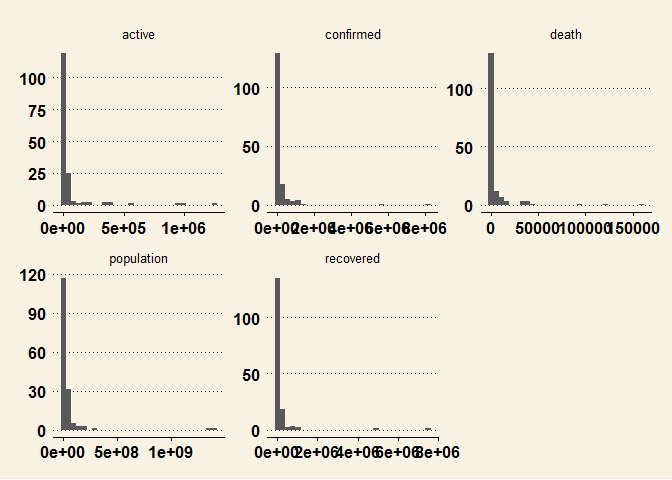

Summary statistics on number of death

| mean | median | std | min | max |
| --- | --- | --- | --- | --- |
| 5472.488 | 320.5 | 18583.42 | 0 | 159884 |

Summary statistics on number of confirmed cases

| mean | median | std | min | max |
| --- | --- | --- | --- | --- |
| 209452 | 21334 | 799982.2 | 2 | 8184082 |

## level - level

does not give better interpretation There are some influential observations that governing the conditional mean.

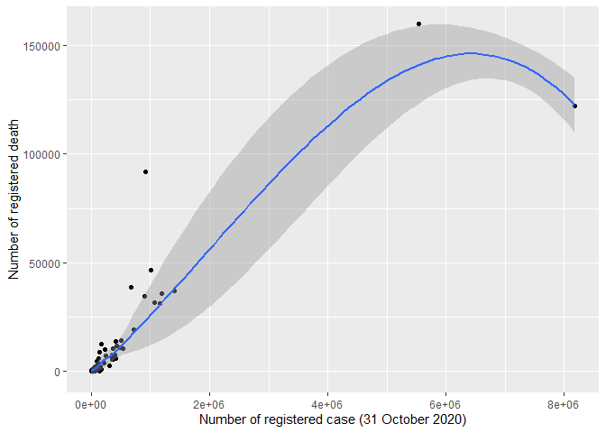

## level y - log x

capturing the non-linearity in data

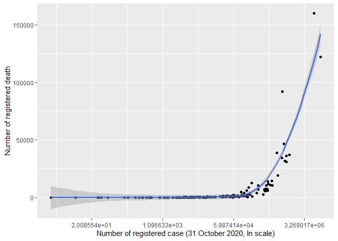

## log y - level x

non-linear

Figure 8.6 A, p214

Most of the observations are very close to each other at the bottom of the distribution of Number of registered cases.

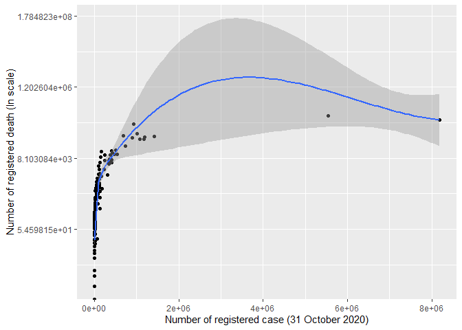

## log y - log x

Taking log of number of registered death and log of number of registered case is making the association close to linear

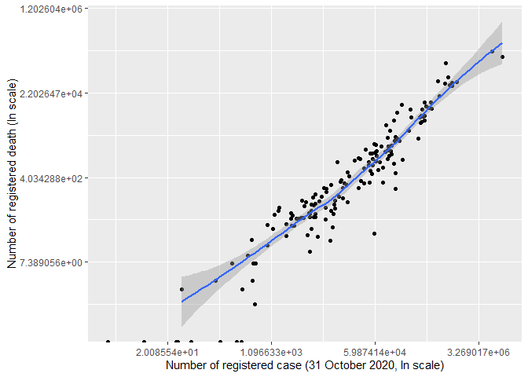

**level y - log x:**

Substantive reasoning: Level changes is harder to interpret Statistical reasoning: log transformation shows the better approximation

**log y - level x:**

Substantive reasoning: it does not give better interpretation Statistical reasoning: log transformation of number of registered death and taking level of number of case does not give good approximation

**log y - log x**

Substantive reasoning: it is easier to interpret the percentage change in number of death per percentage change in confirmed case Statistical reasoning: it shows the better approximation: making the association close to linear

for 5% change in x, we observe 5% change in y value

[^1]: Center for Systems Science and Engineering